# The Power Law Process and Reliability (Observation à horizon T fixé)

## 2.2 Simulation sur $[0, T]$

On tire $N(T) \sim \mathcal{P}\big((T/\alpha)^\beta\big)$. Sachant $N(T) = n$, on pose $T_i = T\,U_{(i)}^{1/\beta}$, où $U_1, \dots, U_n$ sont i.i.d. de loi $\mathcal{U}([0, 1])$ (Proposition « Loi conditionnelle des temps d’arrivée »).

```r
set.seed(42)
w_test <- sim_power_law_process(alpha = 1.0, beta = 1.5, T_end = 50)
cat("Nombre d'événements simulés N(50) :", length(w_test), "\n")
```

```
## Nombre d'événements simulés N(50) : 379
```

```r
cat("Premiers temps d'arrivée T_i :", round(head(w_test, 6), 3), "...\n")
```

```
## Premiers temps d'arrivée T_i : 0.193 0.62 0.676 0.864 0.891 1.249 ...
```

## 2.3 Convergence et biais du MLE

On illustre les Propositions 3.7, 3.11 et 3.12 de Cocozza-Thivent (1997).

```r
sim_outputs <- run_all_illustrations(save_figs = FALSE)
```

```
## Illustrations des Convergences du MLE
```

### 2.3.1 Convergence presque sûre (Proposition 3.7)

Sur une même trajectoire, $\hat{\beta}(t)$ et $\hat{\alpha}(t)$ convergent p.s. vers $\beta$ et $\alpha$ quand $t \to +\infty$. La partie théorique n’en démontre que la convergence en probabilité.

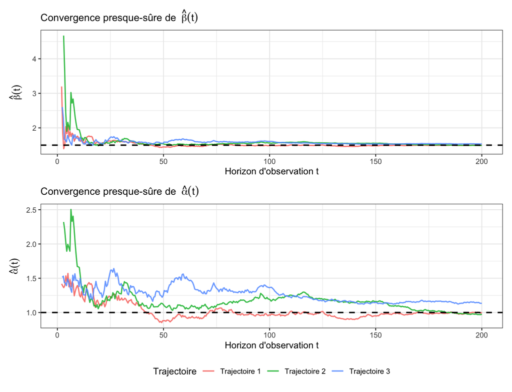

```r
sim_outputs$plots$p_as
```

Sur les trois trajectoires tracées, $\hat{\beta}$ est compris entre 1,62 et 1,95 à $t = 10$ ($N(t) \approx 30$), et entre 1,49 et 1,53 à $t = 200$ ($N(t) \approx 2800$). $\hat{\alpha}$ converge nettement plus lentement : à $t = 200$, il vaut encore entre 0,98 et 1,14. C’est le facteur $\ln t$ de la section suivante.

### 2.3.2 Normalité asymptotique (Propositions 3.11 et 3.12)

Pour $\beta$, la vitesse est $\sqrt{N(t)}$ :
$$Z_{\beta}(t) =
\sqrt{N(t)}\left(\frac{\hat{\beta}}{\beta} - 1\right)
\xrightarrow{\mathcal{L}} \mathcal{N}(0, 1).$$

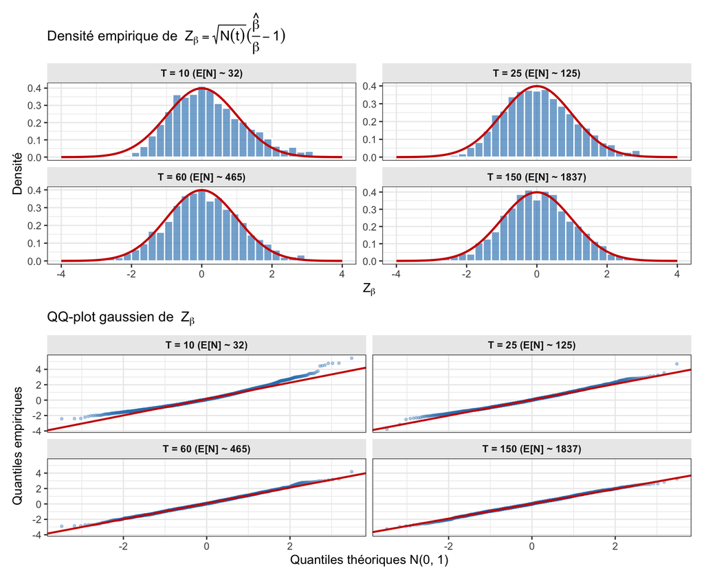

```r
sim_outputs$plots$p_beta_norm
```

À $T = 10$ ($\mathbb{E}[N(T)] \approx 32$), $Z_\beta$ a pour moyenne 0,22 et pour écart-type 1,09 : la distribution est décalée vers la droite, ce qui reflète le biais de $\hat{\beta}$ (voir plus bas). À $T = 150$, la moyenne vaut 0,03 et l’écart-type 0,99.

Pour $\alpha$, la vitesse est divisée par $\ln t$ :
$$Z_{\alpha}(t) = \frac{\sqrt{N(t)}}{\ln
t}\left(\frac{\hat{\alpha}}{\alpha} - 1\right) \xrightarrow{\mathcal{L}}
\mathcal{N}(0, 1).$$

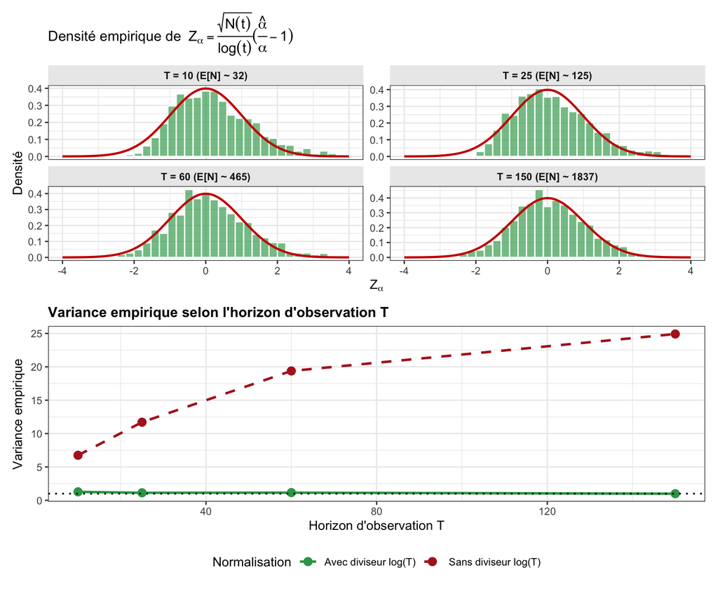

```r
sim_outputs$plots$p_alpha_norm
```

La convergence est plus lente que pour $\beta$ : le coefficient d’asymétrie de $Z_\alpha$ vaut 0,80 à $T = 10$ et encore 0,20 à $T = 150$. Sans le facteur $\ln t$, la variance de $\sqrt{N(t)}\,(\hat{\alpha}/\alpha - 1)$ vaut 6,7, 11,7, 19,4 et 24,9 pour $T = 10, 25, 60, 150$. Elle suit $(\ln T)^2 \approx$ 5,3, 10,4, 16,8 et 25,1, alors que la variance de $Z_\alpha$ reste entre 1,0 et 1,3.

### 2.3.3 Loi limite du couple $(\hat{\alpha}, \hat{\beta})$ (Propositions 3.11-3 et 3.12)

La loi limite du couple renormalisé est dégénérée : elle est portée par une droite. La corrélation limite vaut $-1$ pour la forme 3.a et $+1$ pour la forme 3.b.

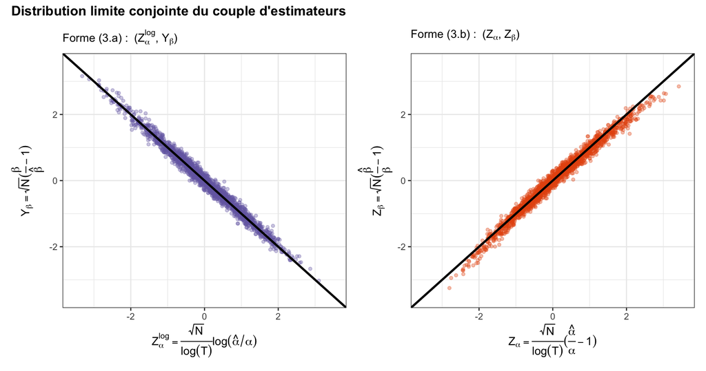

```r
sim_outputs$plots$p_joint
```

À $T = 150$, les corrélations empiriques valent $-0{,}992$ (forme 3.a) et $0{,}990$ (forme 3.b). Asymptotiquement, on surestime donc $\alpha$ exactement quand on surestime $\beta$.

### 2.3.4 Biais de $\hat{\beta}$ à taille finie

Sachant $N(T) = n$, $2n\beta/\hat{\beta} \sim \chi^2(2n)$, donc $\mathbb{E}[\hat{\beta} \mid N(T) = n] = \frac{n}{n-1}\beta$ pour $n \ge 2$. L’estimateur $\tilde{\beta} = \frac{n-1}{n}\hat{\beta}$ est sans biais.

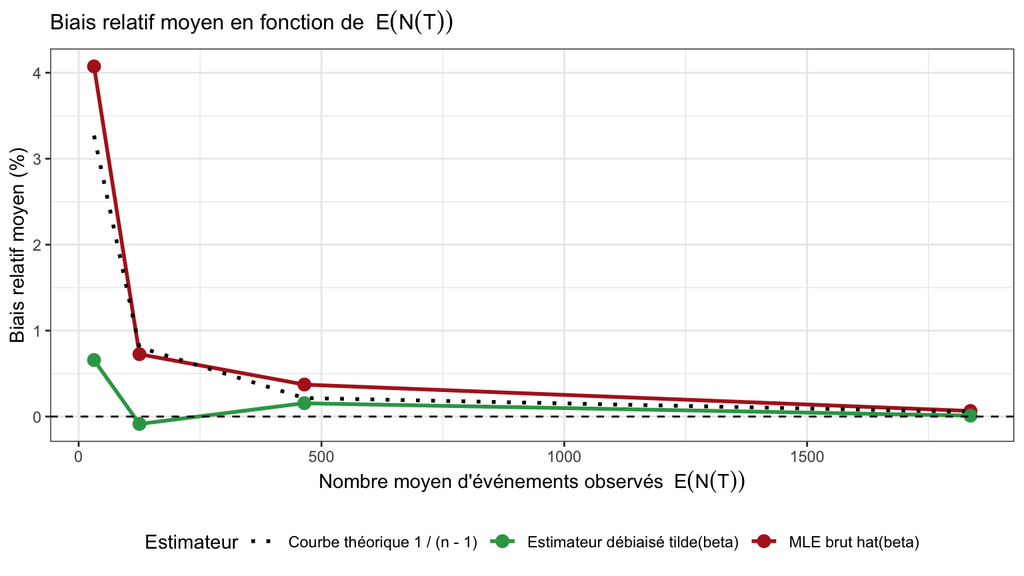

```r
sim_outputs$plots$p_bias
```

À $T = 10$ ($\mathbb{E}[N(T)] \approx 32$), le biais relatif de $\hat{\beta}$ est de $+4{,}1\,\%$, contre $+0{,}7\,\%$ pour $\tilde{\beta}$. Dès $\mathbb{E}[N(T)] \approx 125$, les deux sont inférieurs à $1\,\%$.

## 2.4 Couverture des intervalles de confiance

Pour chaque horizon $T$, on simule $M = 2000$ trajectoires et on compte la proportion d’IC à 95 % qui contiennent la vraie valeur. Avec $M = 2000$, l’erreur Monte-Carlo sur une couverture de 95 % est d’environ $\pm 1$ point.

```r
ci_outputs <- run_all_ci_validation(save_figs = FALSE)
```

```
## =====================================
## 🐟 Validation des IC
## =====================================
##
## 1. Simulation Monte-Carlo des IC (M = 2000 réplications sur 7 horizons T)...
## 2. Génération de la comparaison de couverture et largeur pour beta...
## 3. Génération de la comparaison de couverture et largeur pour alpha...
## 4. Génération de la visualisation des segments d'IC pour beta...
##
## Validation numérique des IC terminée avec succès !
```

### 2.4.1 IC pour $\beta$ : exact ou asymptotique

On compare l’IC exact déduit de la loi $\chi^2(2n)$ (Corollaire 3.6) à l’IC asymptotique gaussien (Corollaire 3.13).

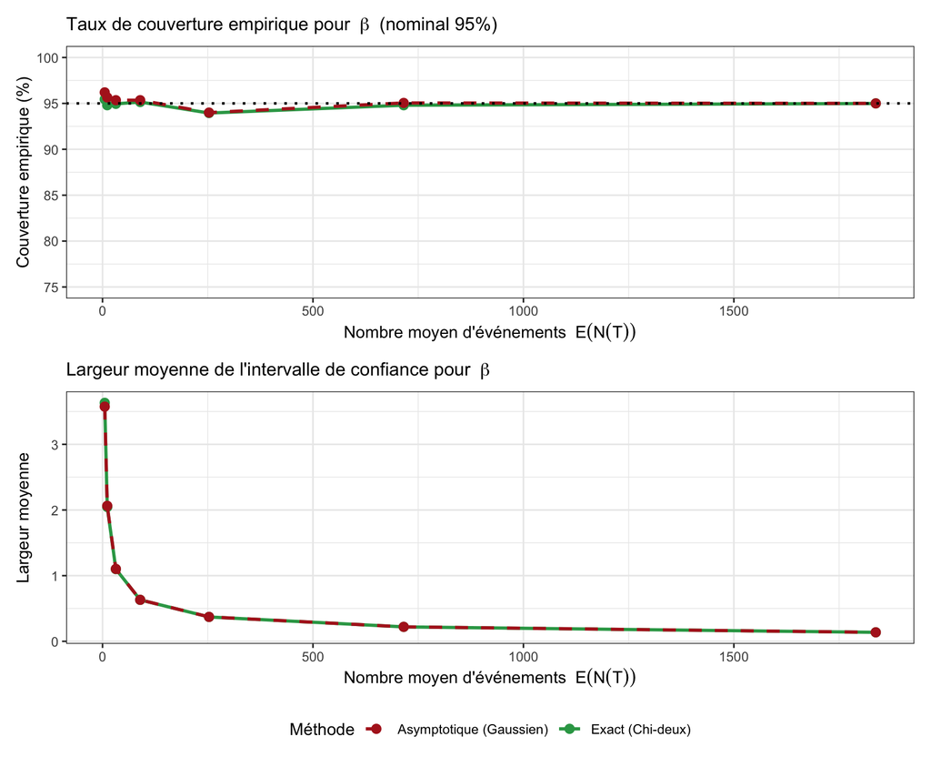

```r
ci_outputs$plots$p_beta
```

L’IC exact couvre entre 94,0 % et 95,5 % à tous les horizons, y compris à $T = 3$ où $\mathbb{E}[N(T)] \approx 5$. L’IC asymptotique a quasiment la même largeur, mais couvre un peu trop aux petits horizons (96,2 % à $T = 3$). À partir de $T = 10$, les deux IC sont indiscernables.

### 2.4.2 IC pour $\alpha$ : forme log ou forme linéaire

On compare la forme log, dont les bornes sont toujours positives, à la forme linéaire du Corollaire 3.13.

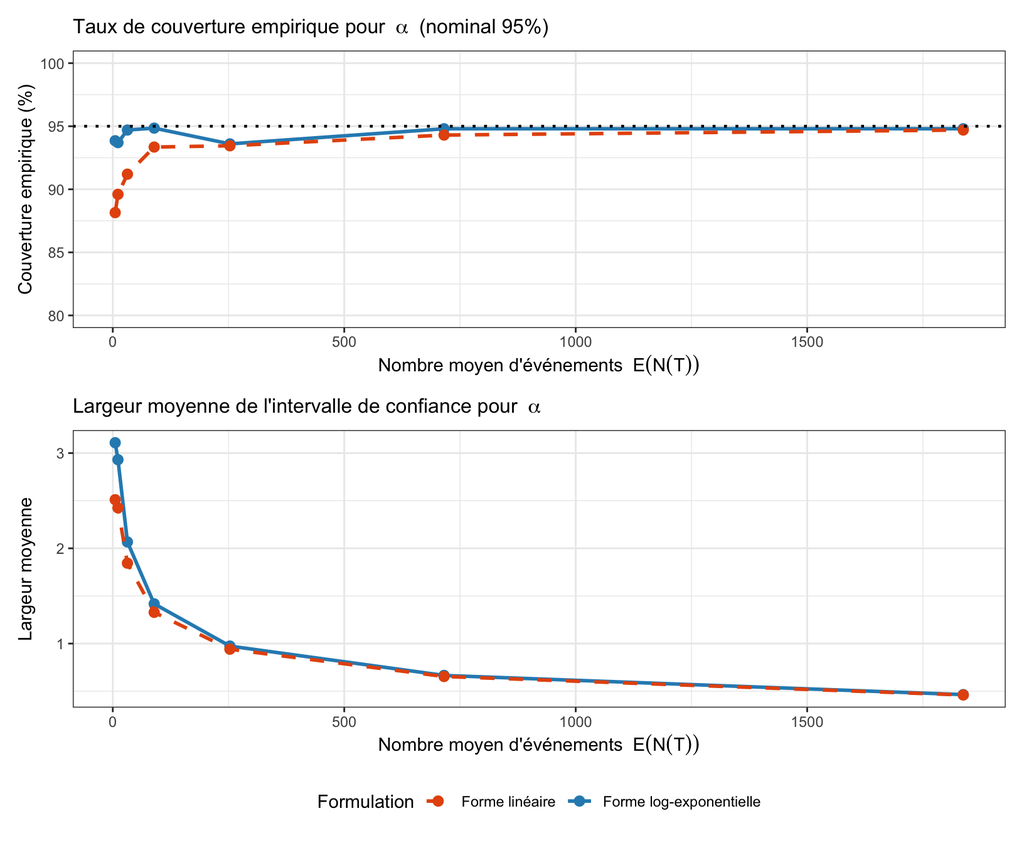

```r
ci_outputs$plots$p_alpha
```

La forme log couvre entre 93,6 % et 94,9 %. La forme linéaire couvre trop peu aux petits horizons (88,1 % à $T = 3$, 91,2 % à $T = 10$), et sa borne inférieure est négative dans 40 % des cas à $T = 3$ et 33 % à $T = 5$. Les deux formes se rejoignent vers $T = 40$ ($\mathbb{E}[N(T)] \approx 250$). Dans tous les cas, l’IC pour $\alpha$ reste large : à $T = 150$ ($\mathbb{E}[N(T)] \approx 1800$), sa largeur vaut 0,46 pour $\alpha = 1$, contre 0,14 pour $\beta = 1{,}5$.

### 2.4.3 Intervalles pour $\beta$ sur un petit échantillon

Intervalles pour $\beta$ obtenus sur 45 réplications à $T = 5$ ($\mathbb{E}[N(T)] \approx 11$).

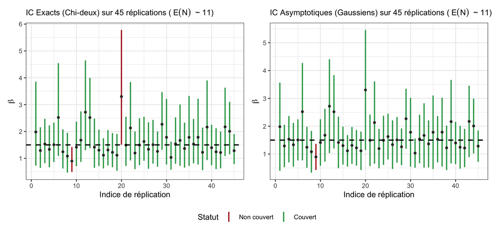

```r
ci_outputs$plots$p_segments
```

Ici, $N(T)$ varie de 6 à 20 d’une réplication à l’autre, et la largeur des intervalles varie en conséquence. L’IC exact manque la vraie valeur 2 fois sur 45, l’IC asymptotique 1 fois. Sur 45 réplications, cette différence n’est pas significative.

## 2.5 Niveau et puissance du test d’adéquation

D’après le Théorème 1 de Møller (1976), sous $H_0$ « les défaillances suivent un processus de Weibull » et sachant $N(T) = n$, les variables $Y_i = \ln(T / T_i)$ sont $n$ observations i.i.d. de loi $\mathcal{E}(\beta)$. On teste leur exponentialité avec la statistique de Kolmogorov-Smirnov, où $\beta$ est remplacé par son MLE $\hat{\beta}$ :
$$D_n = \sup_{x > 0} \left| H_n(x) - \left(1 -
e^{-\hat{\beta} x}\right) \right|.$$
Comme $\hat{\beta}$ est ajusté sur les mêmes données, $D_n$ est plus petit que si $\beta$ était connu : la loi de Kolmogorov ne s’applique plus, et le test qui l’utilise quand même est appelé ici « naïf ». Sous $H_0$, la loi de $D_n$ ne dépend que de $n$, car $\mathcal{E}(\beta)$ est une famille d’échelle et $\hat{\beta}$ est équivariant. On la tabule donc par simulation sous $\mathcal{E}(1)$ (correction de Lilliefors, 1969).

```r
# Niveau : M = 2000 réplications sous H0 (beta = 0.5, 1, 2 ; E[N(T)] de 5 à 150)
# Puissance : M = 1000 réplications par alternative et par E[N(T)]
gof_outputs <- run_all_gof_validation(save_figs = FALSE)
```

```
## BE Poisson : Validation pratique du test d'adéquation (Møller, 1976)
## 1. Niveau empirique sous H0 (M = 2000 réplications par point)...
## 2. Puissance contre les alternatives (M = 1000 réplications par point)...
## 3. Diagrammes des fractiles illustratifs...
##
## Validation numérique du test d'adéquation terminée avec succès !
```

### 2.5.1 Niveau sous $H_0$ : test calibré et test naïf

Taux de rejet au niveau 5 % sur des données simulées sous $H_0$, pour $\beta = 0{,}5$, $1$ et $2$. En bas, la distribution des p-valeurs pour $\mathbb{E}[N(T)] = 20$.

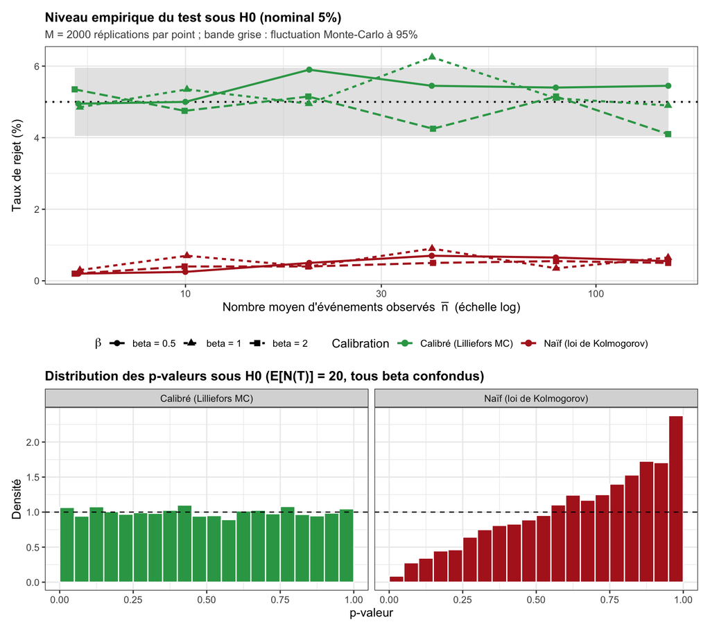

```r
gof_outputs$plots$p_level
```

Le test calibré rejette entre 4,1 % et 6,3 % du temps, quels que soient $\beta$ et $\mathbb{E}[N(T)]$. Sur les 18 configurations, une seule s’écarte de 5 % de plus de 1 point, l’erreur Monte-Carlo : 6,25 % pour $\beta = 1$ et $\mathbb{E}[N(T)] = 40$. Sur 18 configurations, un tel écart n’a rien d’anormal. Ses p-valeurs sont uniformes : chaque décile en contient entre 9,2 % et 10,4 %. Le test naïf rejette au plus 0,9 % du temps, et 20 % de ses p-valeurs dépassent 0,9. Il est donc très conservatif.